# COMPSCIX 415.2 Homework 9/Final

Sumit Pattanayak

April 4, 2019

# Exercise 1:

## Sampling Distributions, Functions and For Loops

### You can sample from this exponential distribution in R using this code:

```r
# sample size
samp_size <- 100
# set the rate parameter
samp_rate <- 1/10000
# take sample
rexp(n = samp_size, rate = samp_rate)
```

```
##   [1] 10771.9704  5824.1708 14883.0642 29145.0717 25257.5879  4384.6234
##   [7]   945.5645   844.2670   603.0107  1565.3578  4392.8636 13171.0770
##  [13]   273.0456 12030.8315  1297.2570  9859.1722 10309.8616  8764.4497
##  [19]  3703.4719 14932.3094  4346.3739  1238.8295 14018.3409 17764.1467
##  [25]  4869.3954 16874.4888  9712.5820  1084.6781 19748.1224 18100.6885
##  [31]  3254.8901  6869.1791 13760.5406  1306.1136 10669.9336  5253.2838
##  [37]  3770.7893  5297.4243  6639.0283 31176.7177  7125.5104 14436.8831
##  [43]  2641.2975  4461.8671  7677.9410  3496.7611  3216.6687 19676.6868
##  [49]  1771.1956  1832.5908 15689.0731  4981.7781  5863.2895  4518.1675
##  [55]  6376.8386  9954.9694 10129.4729 39838.3366 12753.9283  2714.8783
##  [61]  5223.9083  5343.0918  2673.1348  2252.6473 27705.1328  2532.2535
##  [67] 14779.3534  9794.7957  1459.5826  2135.4958 15404.6481 11398.5344
##  [73] 38054.4290   353.6039  7438.6116 15058.2360  4723.2844 13270.7018
##  [79]  3199.3488  5253.1785   240.8150 17094.2419 55122.1804  2804.7005
##  [85] 34277.2035  7010.7544  8003.7544  1167.7631  4814.3863  9029.1188
##  [91] 13936.7100 15698.0534 27276.1547 18221.8307 17552.1372 11783.7388
##  [97] 11804.3240 18133.0858 13673.3346  1812.5079
```

## STEP 1

*Write an R function that does the following:*

*Takes a sample of size samp_size from this exponential distribution (samp_size is an input parameter for the function)* *Calculates the mean of that sample* *Calculates the standard deviation of that sample* *Returns the calculated mean and standard deviation as a list*

```r
samp_fun <- function(samp_size, samp_rate) {
  exp_samp <- rexp(n = samp_size, rate = samp_rate)
  samp_avg = mean(exp_samp)
  samp_std_dev = sd(exp_samp)
  stats <- list(samp_avg = samp_avg, samp_std_dev = samp_std_dev)
return(stats)
}
```

## STEP 2

*Then write a loop that does this:* *• Runs the above function 1000 times, with samp_size = 50 and samp_rate = 1/10000* *• Saves all of the sample means in a vector called sample_means, and all of the sample standard deviations in a vector called sample_sds*

```r
n <- 1000
samp_size = 50

main_function <- function(n,samp_size){
#empty vector for saving sample means and SDs
  sample_means <- rep(NA, n)
  sample_sds <- rep(NA, n)

  for(i in 1:n) {
    x <- samp_fun(samp_size, 1/10000) # save sample mean and sd
    sample_means[i] <- x$samp_avg # add sample mean to vector
    sample_sds[i] <- x$samp_std_dev # add sample sd to vector
  }

# save output in a tibble
  exp_samp_df <- tibble(
    sample_means,
    sample_sds
  )
return(exp_samp_df)
}
main_function(n,samp_size)
```

```
## # A tibble: 1,000 x 2
##    sample_means sample_sds
##           <dbl>      <dbl>
##  1       11444.     11479.
##  2        9357.     12092.
##  3       11477.     11802.
##  4       13030.     12407.
##  5        9190.      8065.
##  6        8281.      9222.
##  7       11033.     12132.
##  8        7904.      9242.
##  9       10905.     11107.
## 10       10369.     10068.
## # ... with 990 more rows
```

## STEP 3

*Then* *• plot your sample means as a histogram* *• output the standard deviation of your sample means* *• calculate the theoretical standard error (σ = 10000, n = sample size)* *• calculate the mean of the sample standard deviations and use this to calculate the empirical standard error* *Plot the sample means*

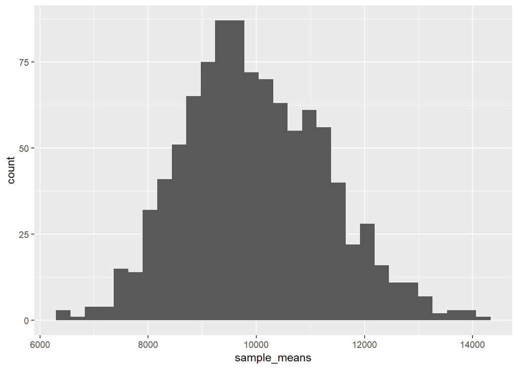

```r
  exp_samp_df <- main_function(n,samp_size)
  plot <- exp_samp_df %>% ggplot(aes(x = sample_means)) +
  geom_histogram()
  plot
```

```r
# Standard deviation of the sample means
  sd_sample_means <- sd(exp_samp_df$sample_means)
  sd_sample_means
```

```
## [1] 1315.167
```

```r
# Calculate the theoretical standard error
  theo_sd_error <- 10000/sqrt(samp_size)
  theo_sd_error
```

```
## [1] 1414.214
```

```r
# Calculate the mean of the sample standard deviations and use this to calculate the   empirical standard error
  mean_sample_sd <- mean(exp_samp_df$sample_sds)/sqrt(samp_size)
  mean_sample_sd
```

```
## [1] 1382.122
```

## STEP 4

*Repeat STEP 2 and STEP 3 using a sample size of 5000*

### for Sample size 5000

```r
#Step 2
samp_size = 5000
main_function(n,samp_size)
```

```
## # A tibble: 1,000 x 2
##    sample_means sample_sds
##           <dbl>      <dbl>
##  1       10034.      9752.
##  2       10067.     10069.
##  3        9995.      9948.
##  4        9990.     10069.
##  5        9940.      9911.
##  6       10009.      9985.
##  7       10074.      9959.
##  8        9983.     10025.
##  9       10136.     10340.
## 10       10026.     10034.
## # ... with 990 more rows
```

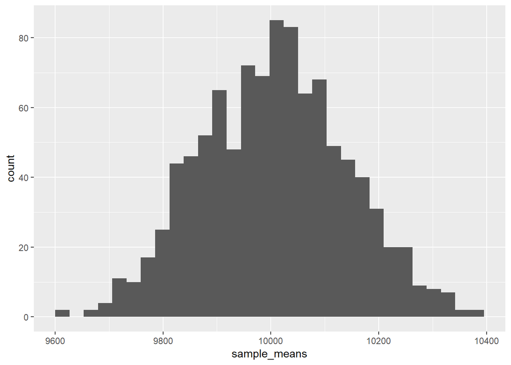

```r
#Step 3
  exp_samp_df <- main_function(n,samp_size)
  plot <- exp_samp_df %>% ggplot(aes(x = sample_means)) +
  geom_histogram()
  plot
```

```r
# Standard deviation of the sample means
  sd_sample_means <- sd(exp_samp_df$sample_means)
  sd_sample_means
```

```
## [1] 134.9489
```

```r
# Calculate the theoretical standard error
  theo_sd_error <- 10000/sqrt(samp_size)
  theo_sd_error
```

```
## [1] 141.4214
```

```r
# Calculate the mean of the sample standard deviations and use this to calculate the   empirical standard error
  mean_sample_sd <- mean(exp_samp_df$sample_sds)/sqrt(samp_size)
  mean_sample_sd
```

```
## [1] 141.5021
```

# Exercise 2:

## Linear Regression

```r
# Load the train.csv dataset
train_df_path <- 'C:/Users/Sumit/Documents/compscix-415-2-assignments/Final/train.csv'
train_df <- read_csv(file = train_df_path)
# Fit a regression model with y = SalePrice and use LotArea, OverallQual, and ExterQual as features
sales_mult_lm <- lm(formula = SalePrice ~ LotArea + OverallQual + ExterQual, data = train_df)
```

*Answer these questions:*

1. Use the broom package to output the coefficients and the R-squared

```r
library(broom)
tidy(sales_mult_lm)
```

```
## # A tibble: 6 x 5
##   term         estimate std.error statistic   p.value
##   <chr>           <dbl>     <dbl>     <dbl>     <dbl>
## 1 (Intercept)  40764.   12358.         3.30 9.95e-  4
## 2 LotArea          1.45     0.116     12.5  3.72e- 34
## 3 OverallQual  34466.    1216.        28.3  4.77e-141
## 4 ExterQualFa -95352.   14592.        -6.53 8.80e- 11
## 5 ExterQualGd -71529.    6737.       -10.6  2.05e- 25
## 6 ExterQualTA -97527.    7541.       -12.9  2.72e- 36
```

```r
glance(sales_mult_lm)
```

```
## # A tibble: 1 x 11
##   r.squared adj.r.squared  sigma statistic p.value    df  logLik    AIC
##       <dbl>         <dbl>  <dbl>     <dbl>   <dbl> <int>   <dbl>  <dbl>
## 1     0.695         0.694 43948.      663.       0     6 -17677. 35368.
## # ... with 3 more variables: BIC <dbl>, deviance <dbl>, df.residual <int>
```

2. Interpret the coefficient on LotArea

Answer: For every one unit increase in LotArea, the sale price increases, on average, by $1.45.

3. Interpret the coefficient on ExterQualGd

Answer: ExterQual is an unordered categorical variable, so the coefficient can be interpreted as a comparison to the first value in ExterQual. Therefore, the mean price difference between ExterQualGd and the first value (ExterQualEx) is -$71,529.

4. Compare this model to the model we fit in HW 7 with GrLivArea, OverallQual, Neighborhood. Which is the better fitting model?

Answer: The model we fit in HW 7 with GrLivArea, OverallQual, Neighborhood had an adjusted R-squared value of 0.78. Our model here does not fit as well, shown by the lower adjusted R-squared value of 0.69. Therefore the model fit for HW 7 is better.

# Exercise 3:

## AB Testing

*Answer these questions:*

1. What proportion of visitors converted for each version of the webpage?

```r
# Load the ab_test_data.csv dataset
ab_test_df_path <- 'C:/Users/Sumit/Documents/compscix-415-2-assignments/Final/ab_test_data.csv'
ab_test_df <- read_csv(file = ab_test_df_path)
ab_test_df$conversion <- as.character(ab_test_df$conversion)

ab_freq_df <- ab_test_df %>% count(version, conversion)

ab_freq_df <- ab_freq_df %>%
  spread(key = conversion, value = n) %>%
  rename(not_converted = '0', converted = '1') %>%
  mutate(total = not_converted + converted,
         prop_converted = converted/total,
         perc_converted = paste0(round(prop_converted*100, 1), "%"))

ab_freq_df
```

```
## # A tibble: 2 x 6
##   version not_converted converted total prop_converted perc_converted
##   <chr>           <int>     <int> <int>          <dbl> <chr>
## 1 A                1917        83  2000         0.0415 4.2%
## 2 B                1800       200  2000         0.1    10%
```

Answer: 4.2 percent of visitors converted for version A and 10 percent of visitors converted for version B.

2. Perform the AB test in R. What is the p-value for the AB test (hypothesis test of proportions)?

```r
samp_a <- ab_freq_df %>% filter(version == "A") %>% select(converted)
samp_a <- samp_a[[1]]
samp_b <- ab_freq_df %>% filter(version == "B") %>% select(converted)
samp_b <- samp_b[[1]]
n_a = n_b = 2000

two_prop_test <- prop.test(c(samp_a, samp_b), c(n_a, n_b))
two_prop_test$p.value
```

```
## [1] 8.479709e-13
```

Answer: The p-value is very small (less than 0.000), which tells us that the conversion rates for Version A and B are significantly different than each other.